# Open Case Studies: Exploring global patterns of obesity across rural and urban regions

Let’s compare the change over time in rural communities to the change in urban communities among women and separately among men.

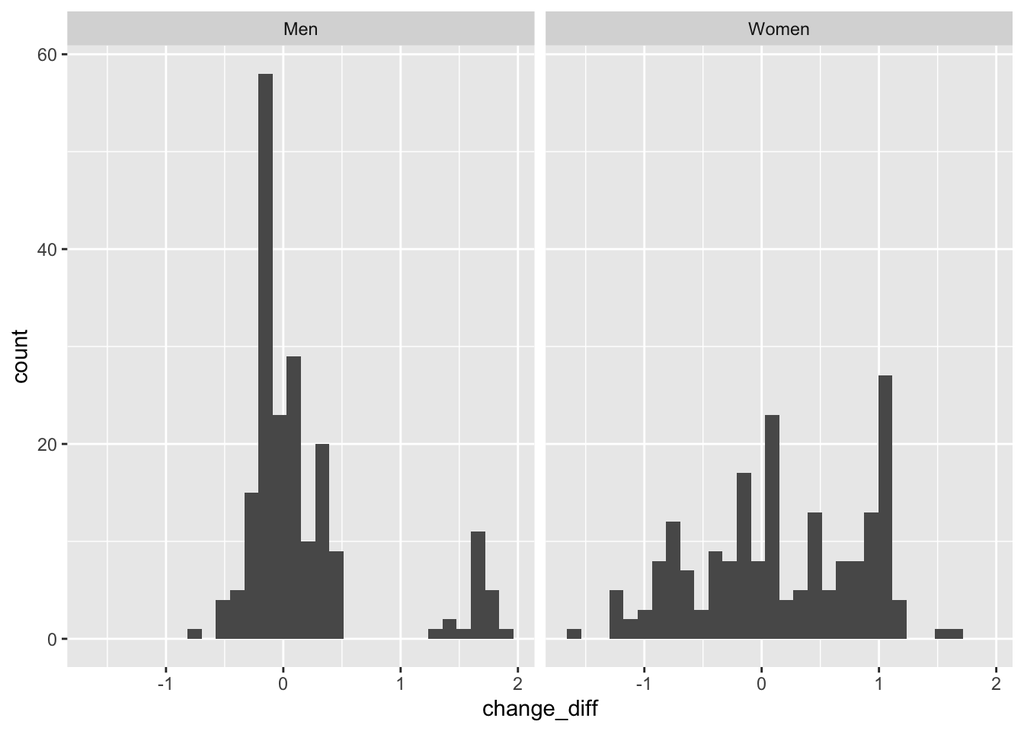

```r
# lets look at the normality of these paired differences
# first we need to calculate the paired differences of change over time
BMI_diff_long %>%
  filter(Difference != "National_difference") %>%
  group_by(Country, Sex) %>%
  summarize(change_rural = value[Difference == "Rural_difference"],
            change_urban = value[Difference == "Urban_difference"],
            change_diff = change_rural - change_urban) %>%
  ggplot(aes(x=change_diff)) +
  geom_histogram() +
  facet_wrap(~ Sex)
```

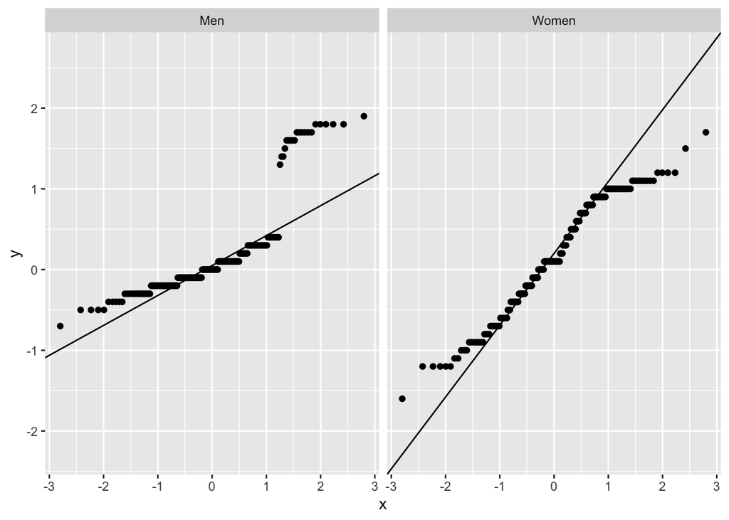

```r
# interesting...the spread of the difference in change over time is much
# broader for women than for men
# for women, the differences look reasonably normal, spread between -1 and +1
# for men there appear to be two groups of countries; one with difference in change over time
# centered around 0 and the other with difference in change over time between 1 and 2.


# Let's look at Q-Q plots:
BMI_diff_long %>%
  filter(Difference != "National_difference") %>%
  group_by(Country, Sex) %>%
  summarize(change_rural = value[Difference == "Rural_difference"],
            change_urban = value[Difference == "Urban_difference"],
            change_diff = change_rural - change_urban) %>%
  ggplot(aes(sample = change_diff)) +
  stat_qq() + # to add the line we need to also include stat_qq_line()
  stat_qq_line() +
  facet_wrap(~ Sex)
```

```r
# the distribution of differences in change over time does not appear normal
# for either men or women
```

Based on the non-normality of these paired differences, we will use a Wilcoxon signed-rank test to compare changes over time between urban and rural areas separately for men and women:

```r
wilcox.test(pull(filter(BMI_diff_long,
                    Sex == "Women",
                    Difference == "Rural_difference"), value),
        pull(filter(BMI_diff_long,
                    Sex == "Women",
                    Difference == "Urban_difference"), value),
        paired = TRUE)
```

```
    Wilcoxon signed rank test with continuity correction

data:  pull(filter(BMI_diff_long, Sex == "Women", Difference == "Rural_difference"), value) and pull(filter(BMI_diff_long, Sex == "Women", Difference == "Urban_difference"), value)
V = 11304, p-value = 0.00327
alternative hypothesis: true location shift is not equal to 0
```

```r
wilcox.test(pull(filter(BMI_diff_long,
                    Sex == "Men",
                    Difference == "Rural_difference"), value),
        pull(filter(BMI_diff_long,
                    Sex == "Men",
                    Difference == "Urban_difference"), value),
        paired = TRUE)
```

```
    Wilcoxon signed rank test with continuity correction

data:  pull(filter(BMI_diff_long, Sex == "Men", Difference == "Rural_difference"), value) and pull(filter(BMI_diff_long, Sex == "Men", Difference == "Urban_difference"), value)
V = 9159, p-value = 0.08256
alternative hypothesis: true location shift is not equal to 0
```

Using a p-value threshold of 0.05, we would conclude there’s a difference in change over time between urban and rural areas for women (p = 0.00327) but not for men (p = 0.08256).

However, now we have performed six comparisons (4 earlier) so we should apply our multiple testing correction and use a new p-value threshold of:

```r
.05/6
```

```
[1] 0.008333333
```

With the threshold adjusted for multiple comparisons, we would still conclude there’s a difference in the change over time between urban and rural areas for women but not for men.

Interestingly, although we don’t see a difference in change over time for men, our histogram of the differences between urban and rural areas for men highlighted two groups of countries – one centered around zero (no difference) and one above 1 (showing a difference):

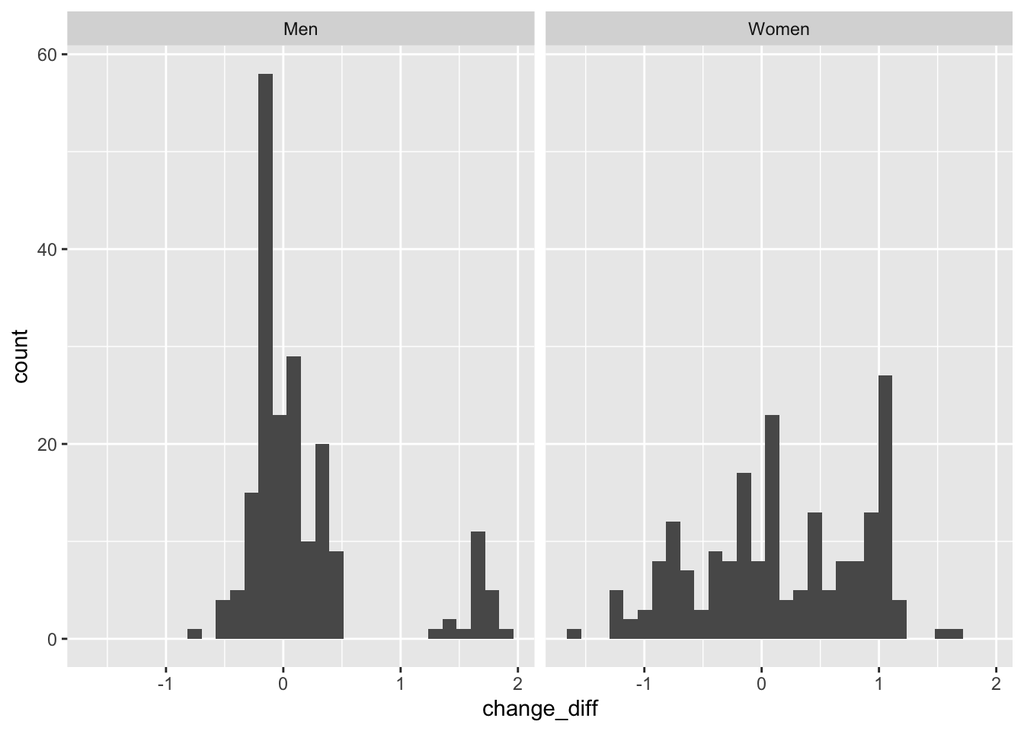

```r
BMI_diff_long %>%
  filter(Difference != "National_difference") %>%
  group_by(Country, Sex) %>%
  summarize(change_rural = value[Difference == "Rural_difference"],
            change_urban = value[Difference == "Urban_difference"],
            change_diff = change_rural - change_urban) %>%
  ggplot(aes(x=change_diff)) +
  geom_histogram() +
  facet_wrap(~ Sex)
```

In fact for these countries, the difference between rural and urban areas for men is higher than the difference for women for almost all of the countries!

We can look to see which countries have such a large difference in change over time between rural and urban areas for men:

```r
BMI_diff_long %>%
  filter(Sex == "Men", Difference != "National_difference") %>%
  group_by(Country) %>%
  summarize(change_rural = value[Difference == "Rural_difference"],
            change_urban = value[Difference == "Urban_difference"],
            change_diff = change_rural - change_urban) %>%
  filter(change_diff > 1)
```

```
# A tibble: 21 × 4
   Country          change_rural change_urban change_diff
   <chr>                   <dbl>        <dbl>       <dbl>
 1 Afghanistan              2.8         1.20         1.60
 2 American Samoa           2           0.200        1.80
 3 Bangladesh               2.3         0.600        1.70
 4 Bhutan                   2.8         1.10         1.70
 5 Cook Islands             3.10        1.40         1.70
 6 Fiji                     3           1.60         1.40
 7 French Polynesia         2.5         0.800        1.7
 8 India                    2.6         0.700        1.90
 9 Kiribati                 2.10        0.5          1.60
10 Marshall Islands         2.5         0.900        1.60
# ℹ 11 more rows
```

```r
BMI_diff_long %>%
  filter(Country == "USA")
```

```
# A tibble: 6 × 4
  Country Sex   Difference          value
  <chr>   <chr> <chr>               <dbl>
1 USA     Men   Rural_difference     3.10
2 USA     Men   Urban_difference     3.1
3 USA     Men   National_difference  3.10
4 USA     Women Rural_difference     3.5
5 USA     Women Urban_difference     3.4
6 USA     Women National_difference  3.40
```

In the US, focus should be placed on **both urban and rural** women to improve this public health issue.

Here we can see the countries that have the largest differences in BMI from 1985-2017:

```r
BMI_diff_long %>%
  filter(value > 4.9) %>%
  arrange(- value)
```

```
# A tibble: 6 × 4
  Country     Sex   Difference          value
  <chr>       <chr> <chr>               <dbl>
1 Egypt       Women Rural_difference      5.9
2 Honduras    Women National_difference   5.6
3 Honduras    Women Rural_difference      5.5
4 Egypt       Women National_difference   5.1
5 Saint Lucia Women Rural_difference      5
6 Honduras    Women Urban_difference      4.9
```

```r
#here we sorted by the highest to lowest values of BMI Difference
```

However it is important to see what the mean BMI values were for these countries in 2017. It could be that the average was underweight in 1985… let’s take a look.

```r
BMI_long %>%
  filter(Country %in% pull(filter(BMI_diff_long, value > 4.9), Country),
                    Sex %in% pull(filter(BMI_diff_long, value > 4.9), Sex),
                    Year =="2017") %>%
  arrange(- BMI)
```

```
# A tibble: 9 × 5
  Country     Sex   Region   Year    BMI
  <chr>       <chr> <chr>    <chr> <dbl>
1 Egypt       Women Urban    2017   32.3
2 Egypt       Women National 2017   31.7
3 Egypt       Women Rural    2017   31.3
4 Saint Lucia Women National 2017   30.5
5 Saint Lucia Women Rural    2017   30.5
6 Saint Lucia Women Urban    2017   30.5
7 Honduras    Women Urban    2017   28.3
8 Honduras    Women National 2017   27.7
9 Honduras    Women Rural    2017   26.9
```

```r
#Here is the data just for the changes in BMI in Egypt
filter(BMI_diff_long, Country == "Egypt") %>%
  arrange(- value)
```

```
# A tibble: 6 × 4
  Country Sex   Difference          value
  <chr>   <chr> <chr>               <dbl>
1 Egypt   Women Rural_difference     5.9
2 Egypt   Women National_difference  5.1
3 Egypt   Women Urban_difference     4.20
4 Egypt   Men   Urban_difference     2.60
5 Egypt   Men   Rural_difference     2.5
6 Egypt   Men   National_difference  2.5
```

Thus rural women in Egypt had the greatest increase in BMI from 1985 to 2017 in this data (5.9) and the average BMI is now over the obesity threshold of 30.

The data suggests that rural women in Egypt and other countries may especially benefit from dietary resources and our interventions and programs to assist with weight management.

## **Summary**

### **Summary Plot**

Now let’s make a plot that summarizes our findings. To do this we will simplify the other plots we made and then combine them together.

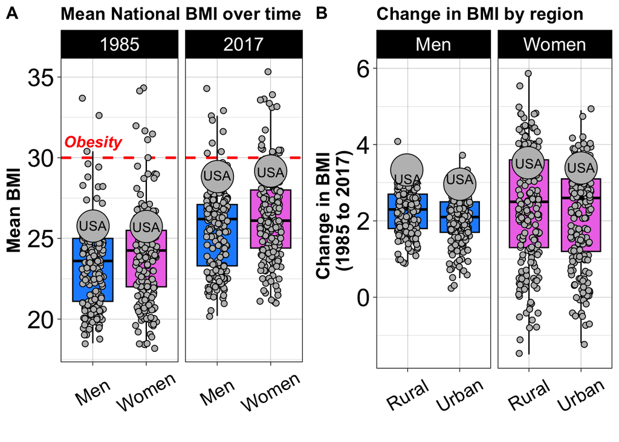

```r
# simplified national means plot
Means_plot<-BMI_long %>%
  filter(Sex %in% c("Men", "Women"),
         Year %in% c("1985", "2017"),
         Region == "National") %>%
ggplot(aes(x = Sex, y = BMI)) +
  geom_boxplot(outlier.shape = NA, color = "black" , aes(fill = Sex)) +
 scale_fill_manual(values=c("dodgerblue", "orchid2")) +
  facet_grid(~ Year) +
  geom_hline(yintercept=30, linetype="dashed", color = "red", size =1) +
  geom_jitter(data=BMI_long %>%
                filter(Sex %in% c("Men", "Women"),
                       Year %in% c("1985", "2017"),
                       Region == "National"),
                aes(x =Sex, y =BMI),
                width = .2, size =2, shape =21,
                color = "black", fill = "gray") +
  geom_jitter(data=subset(BMI_long %>%
                            filter(Sex %in% c("Men", "Women"),
                                   Year %in% c("1985", "2017"),
                                   Region == "National",
                                   Country == "USA")),
                             aes(x =Sex, y =BMI),
                             width = .02, size =12, shape =21,
                             color = "black", fill = "gray") +
  # This will add points that are larger for the USA data
  geom_text(data=subset(BMI_long%>%
                          filter(Sex %in% c("Men", "Women"),
                                 Year %in% c("1985", "2017"),
                                 Region == "National", Country == "USA")),
                          aes(x =Sex, y =BMI,label=Country),
                          color = "black") +
  # This will add USA labels to the USA points
  theme_linedraw() +
  # This will make the background of the plot white and the facet labels black
  theme(legend.position = "none",
  # This is useful for removing the legend
        axis.text.x = element_text(size = 15,angle = 30, vjust = 0.5),
        # this changes the size and angle of the x axis point labels
        axis.text.y = element_text(size = 20),
        axis.title.y = element_text(size =15),
        axis.title.x = element_text(size =15),
        strip.text.x = element_text(size = 15))

#Simplified difference plot
BMI_diff_long[["Difference"]] <-BMI_diff_long[["Difference"]]%>%
  str_replace( pattern = "_difference", replacement = "")

Diff_plot<-BMI_diff_long %>%
  filter(Sex %in% c("Men", "Women"),
         Difference != "National") %>%
ggplot( aes(x = Difference, y = value, col = Difference)) +
  geom_boxplot(outlier.shape = NA, color = "black" , aes(fill = Sex)) +
  scale_fill_manual(values=c("dodgerblue", "orchid2")) +
  facet_grid(~ Sex) +
  geom_jitter(data=BMI_diff_long %>%
    filter(Sex %in% c("Men", "Women"),
           Difference != "National"),
    aes(x =Difference, y = value),
    width = .2, size = 2, shape = 21,
    color = "black", fill = "gray") +
  geom_jitter(data=subset(BMI_diff_long %>%
    filter(Sex %in% c("Men", "Women"),
           Difference != "National",
           Country == "USA")),
    aes(x = Difference, y = value),
    width = .02, size =12, shape =21,
    color = "black", fill = "gray") +
  # This will add points that are larger for the USA data
  geom_text(data=subset(BMI_diff_long %>%
    filter(Sex %in% c("Men", "Women"),
           Difference != "National"),
           Country == "USA"),
    aes(x = Difference, y = value,label=Country),
    color = "black") +
  # This will add USA labels to the USA points
  theme_linedraw() +
    # This will make the background of the plot white and the facet labels black
  theme(legend.position = "none",
  # This is useful for removing the legend
        axis.text.x = element_text(size = 15,angle = 30, vjust = 0.5),
        # this changes the size and angle of the x axis point labels
        axis.text.y = element_text(size = 20),
        axis.title.y = element_text(size =15),
        axis.title.x = element_text(size =15),
        strip.text.x = element_text(size = 15))
  # this changes the size of x axis labels for the facet

#add labels
Diff_plot<-Diff_plot +
        labs(title = "Change in BMI by region",
             x = "",
             y = "Change in BMI \n (1985 to 2017)") +
        theme(title = element_text (size = 12, face = "bold"))

Means_plot <-Means_plot +
        labs(title = "Mean National BMI over time",
             x = "",
             y = "Mean BMI") +
        theme(title = element_text (size = 12, face = "bold"))



obesity_text<-tibble(Year=c(1985),BMI=c(31),Sex=c("Men"),label=c("Obesity"))

Means_plot <-Means_plot +
             geom_text(data = obesity_text,
                       label=pull(obesity_text,label),
                       color = "red",
                       aes( fontface ="bold.italic", size = 13))

cowplot::plot_grid(Means_plot, Diff_plot, labels = c("A", "B"))
```

We could make a similar plot with the `patchwork` package:

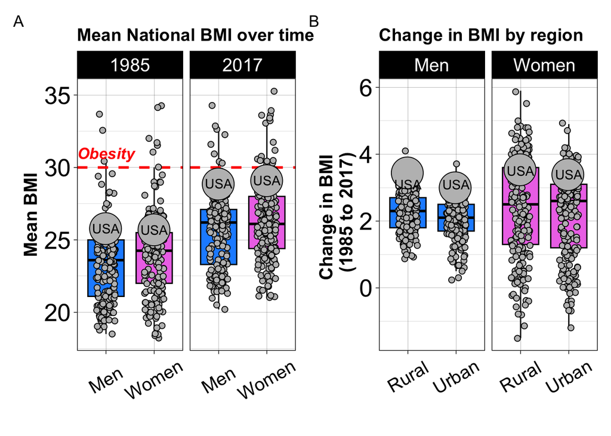

```r
Means_plot +labs(tag = 'A') + Diff_plot+ labs(tag = 'B') +
  plot_layout(guides = 'collect', ncol = 2)
```

Great, now we have put two plots together using the `plot_grid()` function of the `cowplot` package. This way we can clearly communicate two messages. The first being that BMI has increased over time globally and that many countries including the United States of America are approaching a mean BMI that is above the obesity threshold of 30. We can also see that women on average have larger BMI values than males, but that both genders show increased levels over time. In the second plot we can see that the increase in BMI is not just happening in urban communities, but in both rural and urban communities and particularly in women.

Our plot visually explores all of our main questions: 1) Is there a difference between rural and urban BMI estimates around the world? In particular, how does this look for females? 2) How have BMI estimates changed from 1985 to 2017? Again, In particular, how does this look for females? 3) How do different countries compare for BMI estimates? In particular, how does the United States compare to the rest of the world?

Now let’s save our plot as a png file using the `png()` function:

```r
png(here::here("img", "main_plot.png"), height = 1500, width = 2300, res = 300)
cowplot::plot_grid(Means_plot, Diff_plot, labels = c("A", "B"))
dev.off()
```

You might think that these two plots look a bit odd together, that if you look at the change in the boxplots in part A, that the data for Men shows a bigger change, however, we can’t tell from this plot how the individual countries are changing. Part B of the figure looks at the specific change for each country.

We could check our plot using the following code:

```r
BMI_diff_long %>%
  group_by(Sex, Difference) %>%
  filter(!is.na(value))%>%
  filter(Country == "USA") %>%
  summarize(mean = mean(value), median = median(value))
```

```
# A tibble: 6 × 4
# Groups:   Sex [2]
  Sex   Difference  mean median
  <chr> <chr>      <dbl>  <dbl>
1 Men   National    3.10   3.10
2 Men   Rural       3.10   3.10
3 Men   Urban       3.1    3.1
4 Women National    3.40   3.40
5 Women Rural       3.5    3.5
6 Women Urban       3.4    3.4
```

```r
BMI_diff_long %>%
  group_by(Sex, Difference) %>%
  filter(!is.na(value))%>%
  summarize(mean = mean(value), median = median(value))
```

```
# A tibble: 6 × 4
# Groups:   Sex [2]
  Sex   Difference  mean median
  <chr> <chr>      <dbl>  <dbl>
1 Men   National    2.26   2.20
2 Men   Rural       2.23   2.30
3 Men   Urban       2.05   2.10
4 Women National    2.37   2.7
5 Women Rural       2.38   2.5
6 Women Urban       2.21   2.60
```

```r
BMI_long %>%
  group_by(Sex, Year, Region) %>%
  filter(!is.na(BMI))%>%
  filter(Country == "USA") %>%
  summarize(mean = mean(BMI), median = median(BMI))
```

```
# A tibble: 12 × 5
# Groups:   Sex, Year [4]
   Sex   Year  Region    mean median
   <chr> <chr> <chr>    <dbl>  <dbl>
 1 Men   1985  National  25.8   25.8
 2 Men   1985  Rural     26.1   26.1
 3 Men   1985  Urban     25.7   25.7
 4 Men   2017  National  28.9   28.9
 5 Men   2017  Rural     29.2   29.2
 6 Men   2017  Urban     28.8   28.8
 7 Women 1985  National  25.7   25.7
 8 Women 1985  Rural     26     26
 9 Women 1985  Urban     25.6   25.6
10 Women 2017  National  29.1   29.1
11 Women 2017  Rural     29.5   29.5
12 Women 2017  Urban     29     29
```

```r
BMI_long %>%
  group_by(Sex, Year, Region) %>%
  filter(!is.na(BMI))%>%
  summarize(mean = mean(BMI), median = median(BMI))
```

```
# A tibble: 12 × 5
# Groups:   Sex, Year [4]
   Sex   Year  Region    mean median
   <chr> <chr> <chr>    <dbl>  <dbl>
 1 Men   1985  National  23.4   23.6
 2 Men   1985  Rural     23.0   23.2
 3 Men   1985  Urban     23.8   24.1
 4 Men   2017  National  25.6   26.2
 5 Men   2017  Rural     25.2   25.8
 6 Men   2017  Urban     25.9   26.3
 7 Women 1985  National  24.0   24.2
 8 Women 1985  Rural     23.6   23.9
 9 Women 1985  Urban     24.6   24.6
10 Women 2017  National  26.4   26.1
11 Women 2017  Rural     26.0   26.2
12 Women 2017  Urban     26.8   26.4
```

```r
BMI_numeric %>%
  group_by(Sex)%>%
  summarize(Nat_mean1985 = mean(National_BMI_1985),
            Nat_mean2017 = mean(National_BMI_2017))
```

```
# A tibble: 2 × 3
  Sex   Nat_mean1985 Nat_mean2017
  <chr>        <dbl>        <dbl>
1 Men           23.4         25.6
2 Women         24.0         26.4
```

```r
BMI_numeric %>%
  group_by(Sex)%>%
  summarize(Nat_med1985 = median(National_BMI_1985),
            Nat_med2017 = median(National_BMI_2017))
```

```
# A tibble: 2 × 3
  Sex   Nat_med1985 Nat_med2017
  <chr>       <dbl>       <dbl>
1 Men          23.6        26.2
2 Women        24.2        26.1
```

We can see that the largest changes occur for Women.

Scroll through the output!

```r
BMI_diff_long %>%
  filter(value>3.5) %>%
  arrange(-value) %>%
  # this allows us to show the full output
  print(n = 1e3)
```

```
# A tibble: 117 × 4
    Country                          Sex   Difference value
    <chr>                            <chr> <chr>      <dbl>
  1 Egypt                            Women Rural       5.9
  2 Honduras                         Women National    5.6
  3 Honduras                         Women Rural       5.5
  4 Egypt                            Women National    5.1
  5 Saint Lucia                      Women Rural       5
  6 Honduras                         Women Urban       4.9
  7 El Salvador                      Women Rural       4.8
  8 Mexico                           Women Rural       4.8
  9 Uzbekistan                       Women Rural       4.8
 10 Dominican Republic               Women Rural       4.8
 11 Comoros                          Women Urban       4.7
 12 Nicaragua                        Women Rural       4.7
```

[output cut: 105 more lines]

We have evaluated BMI average estimates from 200 different countries around the world. To do so we imported data from a pdf using the `pdftools` package. We used `tidyverse` packages such as `dplyr`, `stringr`, and `tidy` to clean the data and get it in a workable format. Our statistical analysis focused on evaluating differences in BMI in females around the world across time and between rural and urban areas. We found a significant difference both between years and between the type of community among women globally using [paired $t$-tests](https://stattrek.com/hypothesis-test/paired-means.aspx#example1) and [nonparametric](https://www.mayo.edu/research/documents/parametric-and-nonparametric-demystifying-the-terms/doc-20408960) tests. Thus BMI has increased in women since 1985. Although BMI estimates are significantly higher in Urban areas compared to rural areas, BMI estimates have increased in both regions. We learned that there are assumptions and considerations to keep in mind when performing tests that compare two groups.

We learned that the two sample $t$-test relies on:

1. normality of the data for both groups (this is not as much of an issue if the number of observations is relatively large total n>30)
2. equal variance between the two groups (make sure you do the correct test if the data is not normal)
3. independent observations

We learned that we can evaluate if our data is [normally distributed](https://www.physiology.org/doi/full/10.1152/advan.00064.2017) by plotting the distribution and by creating Q-Q plots.

We learned that if our data is not normally distributed, we can consider these options:

1. We can still perform a $t$-test if our n is large
2. We can transform the data before performing a $t$-test

We learned that if our data has unequal variance, we can consider using the [Welch’s $t$-test](https://www.statisticshowto.datasciencecentral.com/welchs-test-for-unequal-variances/).

Importantly, we learned that when we have [paired data](https://www.statisticshowto.datasciencecentral.com/paired-data/) (are observations are not independent) and we intend to compare means, we should perform a paired test ([paired $t$-test](https://stattrek.com/hypothesis-test/paired-means.aspx#example1) or the nonparametric Wilcoxon signed rank test. Our data used in this case study was paired because observations were taken for the same countries for different categories of populations - thus, we wanted to compare these populations within the same country (male vs female, rural vs urban etc.). Other examples would be in a case-control study (if samples are matched for various demographics) or a study with repeated measures (for example, symptom measures from the same individual before and after a treatment). We learned that [paired $t$-test](https://stattrek.com/hypothesis-test/paired-means.aspx#example1) tests a different hypothesis the two-sample $t$-test. In this case we are testing the differences among the pairs of observations and how close these differences are to zero, thus there is only one variance, the variance of the paired differences and therefore, we do not need to worry about the equality of variance assumption like we do with the two-sample $t$test. We learned that we can perform a paired $t$-test by adding the option `paired = TRUE` to the `t.test()` command.

The paired $t$-test assumes that:

1. The paired differences are [normally distributed](http://onlinestatbook.com/2/introduction/distributions.html), which we can evaluate using Q-Q plots or plotting the distribution of the differences.
2. The paired differences are [independent](https://www.stat.cmu.edu/~cshalizi/36-220/lecture-5.pdf) (meaning that observations do not influence each other).

We learned that if the normality assumption is violated, we can use the Wilcoxon signed rank test, or if our data is large enough, due to the central limit theorem, the paired $t$-test should still be robust to deviations from normality.

Using the `ggplot2` package we were able to visualize trends in the data. Importantly, the largest increase appears to be in the rural areas particularly for women. We were also able to identify how the US compared to other countries and which countries showed the largest increase in BMI over time. Analyses like this are important for defining which groups could benefit the most from interventions, education, and policy changes when attempting to mitigate public health challenges. You can see in the [article](https://www.nature.com/articles/s41586-019-1171-x.pdf) that this data came from that many additional considerations would be involved to perform such an analysis.

## **Suggested Homework**

Students can evaluate the change in BMI over time using the global data available for each year between 2015 and 2017. The data can be found [here](https://ncdrisc.org/).

# **More Case Studies**

Interested in exploring more open case studies? Visit **opencasestudies.org** to access additional studies and open educational resources.

## **Additional Information**

### **Helpful Links**

[BMI](https://www.cdc.gov/bmi/adult-calculator/bmi-categories.html)  
[Long and Wide Data Formats](https://r4ds.hadley.nz/data-tidy.html)  
[Distributions](http://onlinestatbook.com/2/introduction/distributions.html) [Normal Distribution](http://onlinestatbook.com/2/introduction/distributions.html) [Skewed Distributions](http://onlinestatbook.com/2/glossary/skew.html) [Bimodal Distribution](http://onlinestatbook.com/2/introduction/distributions.html) [ggplot2](https://ggplot2.tidyverse.org/)  
[Q-Q Plots](http://onlinestatbook.com/2/advanced_graphs/q-q_plots.html)  
[Student $t$-test](https://stattrek.com/statistics/dictionary.aspx?definition=two-sample%20t-test)  
[Paired Data](https://www.ncbi.nlm.nih.gov/pmc/articles/PMC5579465/)  
[Welch’s $t$-test](https://www.statisticshowto.datasciencecentral.com/welchs-test-for-unequal-variances/)  
[Parametric and Nonparametric Methods](https://www.mayo.edu/research/documents/parametric-and-nonparametric-demystifying-the-terms/doc-20408960)  
[Variance](https://stattrek.com/statistics/dictionary.aspx?definition=variance)  
[Balanced Study Design](https://www.statisticshowto.datasciencecentral.com/balanced-and-unbalanced-designs/)  
[Independent Observations](https://www.stat.cmu.edu/~cshalizi/36-220/lecture-5.pdf)  
[Transformation](https://www.statisticshowto.datasciencecentral.com/transformation-statistics/)  
[Permutation/Resampling Methods](https://jhu-advdatasci.github.io/2019/lectures/21-resampling-techniques.html)  
[Central Limit Theorem](https://www.analyticsvidhya.com/blog/2019/05/statistics-101-introduction-central-limit-theorem/)  
[Mood’s Two-Sample Scale Test](https://files.eric.ed.gov/fulltext/ED065559.pdf)  
[Wilcoxon Signed Rank Test](http://www.biostathandbook.com/wilcoxonsignedrank.html)  
[Wilcoxon Rank Sum Test](http://sphweb.bumc.bu.edu/otlt/mph-modules/bs/bs704_nonparametric/BS704_Nonparametric4.html)  
[Two-sample Kolmogorov-Smirnov Test](https://www.itl.nist.gov/div898/software/dataplot/refman1/auxillar/ks2samp.htm)  
[Type 1 Error](https://web.ma.utexas.edu/users/mks/statmistakes/errortypes.html)  
[p-value](https://towardsdatascience.com/p-values-explained-by-data-scientist-f40a746cfc8)  
[Multiple Testing](https://online.stat.psu.edu/stat200/lesson/6/6.3)  
[Bonferroni Method of Multiple Testing Correction](http://mathworld.wolfram.com/BonferroniCorrection.html)

**Packages used in this case study:**

| Package | Use in this case study |
| --- | --- |
| here | to easily load and save data with relative paths |
| [pdftools](https://cran.r-project.org/web/packages/pdftools/pdftools.pdf) | to read a text from pdf into R |
| [stringr](https://stringr.tidyverse.org/articles/stringr.html) | to manipulate the text data |
| [readr](https://readr.tidyverse.org/) | to manipulate the text data within the pdf into individual lines |
| [dplyr](https://dplyr.tidyverse.org/) | to arrange/filter/select subsets of the data |
| [tibble](https://tibble.tidyverse.org/) | to create data objects that we can manipulate with `dplyr`/`stringr`/`tidyr`/`purrr` |
| [glue](https://www.tidyverse.org/blog/2017/10/glue-1.2.0/) | to paste or combine character strings and data together |
| [purrr](https://purrr.tidyverse.org/) | to perform functions on all columns of a tibble |
| [tidyr](https://tidyr.tidyverse.org/) | to convert data from ‘wide’ to ‘long’ format |
| [ggplot2](https://ggplot2.tidyverse.org/) | to make visualizations with multiple layers |
| [ggrepel](https://cran.r-project.org/web/packages/ggrepel/vignettes/ggrepel.html) | to allow labels in figures not to overlap |
| [cowplot](https://cran.r-project.org/web/packages/cowplot/vignettes/introduction.html) and patchwork | to allow plots to be combined |

**Estimate of RMarkdown Compilation Time:**

```
About 16 - 26 seconds
```

This compilation time was measured on a PC machine operating on Windows 10. This range should only be used as an estimate as compilation time will vary with different machines and operating systems.

### **Acknowledgments**

We would like to acknowledge [Jessica Fanzo](https://www.jhsph.edu/faculty/directory/profile/3380/jessica-fanzo) for assisting in framing the major direction of the case study.

We would like to acknowledge [Michael Breshock](https://mbreshock.github.io/) for his contributions to this case study and developing the `OCSdata` package.

We would also like to acknowledge the [Bloomberg American Health Initiative](https://americanhealth.jhu.edu/) for funding this work.